# Tema 2.2. Manipulación de datos

# 2 Importar y renombrar datos

Vamos a trabajar con datos de Tidytuesday y de las librerias de tidyverse principalmente. En todos los casos son datos reales.

Tidytuesday es un proyecto comunitario de ciencia de datos impulsado por la comunidad de R, especialmente por usuarios de tidyverse. Cada martes se publica un dataset limpio y listo para analizar, junto con una breve descripción y enlaces a la fuente original.

[figure not shown]

TidyTuesday

Para aprender a leer y limpiar datos (que es el objetivo de tidyTuesday), vamos a trabajar con un set de datos de esta planaforma; en este caso datos cuisine:

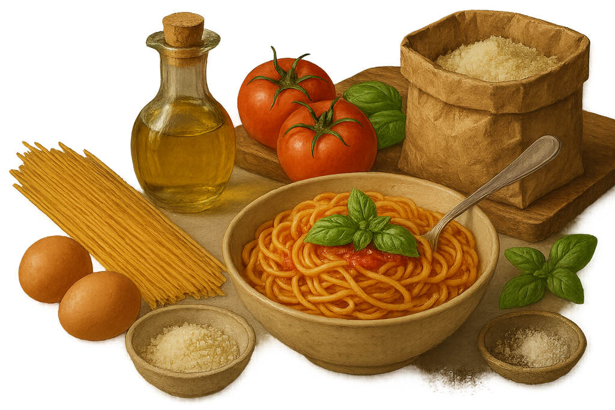

## 2.1 🍽️ **CUISINE** |

El dataset de **Cuisine** de TidyTuesday recopila información sobre recetas y tipos de cocina (origen, valor nutricional, tiempo de preparación etc.).ç

Nos permitirá trabajar con variables que describen diferentes características de las recetas y explorar cómo se organiza esta información en una base de datos.

El archivo `cuisines.csv` contiene 2.218 recetas y 17 variables. Cada fila corresponde a una receta y las columnas incluyen país o región de origen, ingredientes, información nutricional, tiempos de preparación y cocinado, número de raciones y valoraciones de los usuarios.

Los datos reales **pueden contener errores**. Por ejemplo, la documentación advierte que algunos recuentos de valoraciones y reseñas están truncados y que el tiempo total no siempre incluye periodos de espera, refrigeración o marinado. Es necesario revisar la calidad de los datos antes de analizarlos

### 2.1.1 [Read_delim](https://readr.tidyverse.org/reference/read_delim.html): leer datos desde fuera de R

Leer datos que tenemos almacenados, como por ejemplo, una tabla en formato csv.

```r
library(tidyverse)

recetas <- read_delim(file = "data/cuisines.csv",
                      delim = ",")  # con el argumento col_type puedo especificar el tipo de dato (en este caso country como factor)
recetas <- read_delim(
  file = "data/cuisines.csv",
  delim = ",",
  col_type = list(country = "f", servings = "f")
)

recetas
```

```
# A tibble: 2,218 × 17
   name     country url   author date_published ingredients calories   fat carbs
   <chr>    <fct>   <chr> <chr>  <date>         <chr>          <dbl> <dbl> <dbl>
 1 Saganak… Greek   http… John … 2024-02-07     1 (4 ounce…      391    25    15
 2 Coney I… Jewish  http… John … 2024-11-26     2 ¾ cups a…      301    17    31
 3 Diana's… Austra… http… CHIPP… 2022-07-14     1 ½ cups w…       64     3     9
 4 Chilean… Chilean http… Heidi  2025-01-31     ½ cup chop…      106     9     7
 5 Tex-Mex… Tex-Mex http… Ann    2025-02-18     2 cups all…      449    23    58
 6 Newfoun… Canadi… http… MomWh… 2022-08-12     1 (3 pound…      958    24   144
 7 Pasta e… Italian http… Buckw… 2023-12-12     1 cup dry …      378    10    59
 8 Danish … Danish  http… TheOt… 2020-06-19     4 cups all…       90     5    10
 9 Lemon P… Amish … http… Laura… 2025-01-21     2 cups all…      157     6    25
10 Pan con… Spanish http… Luis … 2025-06-02     1 large to…      322    16    39
# ℹ 2,208 more rows
# ℹ 8 more variables: protein <dbl>, avg_rating <dbl>, total_ratings <dbl>,
#   reviews <dbl>, prep_time <dbl>, cook_time <dbl>, total_time <dbl>,
#   servings <fct>
```

```r
View(recetas)
summary(recetas)
```

```
        name                              country            url
 Length   :2218   Canadian                    :  67   Length   :2218
 N.unique :2216   Brazilian                   :  67   N.unique :2218
 N.blank  :   0   Filipino                    :  66   N.blank  :   0
 Min.nchar:   4   Australian and New Zealander:  65   Min.nchar:  45
 Max.nchar:  87   Cuban                       :  65   Max.nchar: 120
                  Chinese                     :  65
                  (Other)                     :1823
       author     date_published          ingredients      calories
 Length   :2218   Min.   :2009-02-09   Length   :2218   Min.   :   3.0
 N.unique :1635   1st Qu.:2022-11-02   N.unique :2217   1st Qu.: 190.0
 N.blank  :   0   Median :2024-07-14   N.blank  :   0   Median : 319.5
 Min.nchar:   1   Mean   :2023-10-27   Min.nchar:  29   Mean   : 358.4
 Max.nchar:  35   3rd Qu.:2025-01-06   Max.nchar:1109   3rd Qu.: 477.0
                  Max.   :2025-07-29   NAs      :   1   Max.   :2266.0
                                                        NAs    :32
      fat             carbs           protein         avg_rating
 Min.   :  0.00   Min.   :  1.00   Min.   :  0.00   Min.   :1.000
 1st Qu.:  7.00   1st Qu.: 13.00   1st Qu.:  4.00   1st Qu.:4.300
 Median : 15.00   Median : 26.00   Median : 11.00   Median :4.600
 Mean   : 18.76   Mean   : 31.96   Mean   : 16.61   Mean   :4.509
 3rd Qu.: 26.00   3rd Qu.: 45.00   3rd Qu.: 25.00   3rd Qu.:4.800
 Max.   :225.00   Max.   :264.00   Max.   :159.00   Max.   :5.000
 NAs    :55       NAs    :35       NAs    :39       NAs    :97
 total_ratings       reviews         prep_time        cook_time
 Min.   :  1.00   Min.   :  1.00   Min.   :   0.0   Min.   :  0.00
 1st Qu.:  6.00   1st Qu.:  6.00   1st Qu.:  10.0   1st Qu.: 10.00
 Median : 24.00   Median : 21.00   Median :  15.0   Median : 25.00
 Mean   : 85.25   Mean   : 76.93   Mean   :  21.5   Mean   : 41.75
 3rd Qu.: 87.00   3rd Qu.: 74.00   3rd Qu.:  25.0   3rd Qu.: 45.00
 Max.   :997.00   Max.   :975.00   Max.   :1800.0   Max.   :600.00
 NAs    :97       NAs    :108
   total_time       servings
 Min.   :    0   4      :487
 1st Qu.:   35   6      :419
 Median :   60   8      :396
 Mean   :  171   12     :238
 3rd Qu.:  120   10     :104
 Max.   :14440   (Other):572
                 NAs    :  2
```

```r
glimpse(recetas)
```

```
Rows: 2,218
Columns: 17
$ name           <chr> "Saganaki (Flaming Greek Cheese)", "Coney Island Knishe…
$ country        <fct> Greek, Jewish, Australian and New Zealander, Chilean, T…
$ url            <chr> "https://www.allrecipes.com/recipe/263750/flaming-greek…
$ author         <chr> "John Mitzewich", "John Mitzewich", "CHIPPENDALE", "Hei…
$ date_published <date> 2024-02-07, 2024-11-26, 2022-07-14, 2025-01-31, 2025-0…
$ ingredients    <chr> "1 (4 ounce) package kasseri cheese, 1 tablespoon water…
$ calories       <dbl> 391, 301, 64, 106, 449, 958, 378, 90, 157, 322, 4, NA, …
$ fat            <dbl> 25, 17, 3, 9, 23, 24, 10, 5, 6, 16, 0, NA, 21, 2, 66, 8…
$ carbs          <dbl> 15, 31, 9, 7, 58, 144, 59, 10, 25, 39, 1, NA, 16, 63, 7…
$ protein        <dbl> 16, 7, 1, 1, 7, 46, 14, 1, 2, 7, 0, NA, 28, 6, 54, 17, …
$ avg_rating     <dbl> 4.8, 4.6, 4.3, 5.0, 3.8, 4.4, 4.3, NA, 4.6, 5.0, 4.7, 4…
$ total_ratings  <dbl> 25, 10, 126, 1, 13, 40, 3, NA, 65, 2, 182, 2, 19, 16, 9…
$ reviews        <dbl> 22, 9, 104, 1, 11, 32, 3, NA, 55, 2, 138, 2, 15, 16, 84…
$ prep_time      <dbl> 10, 30, 20, 10, 30, 30, 30, 40, 0, 5, 5, 5, 10, 10, 20,…
$ cook_time      <dbl> 5, 75, 15, 0, 15, 165, 75, 30, 0, 5, 0, 25, 10, 50, 16,…
$ total_time     <dbl> 15, 180, 180, 10, 45, 675, 585, 155, 0, 10, 5, 30, 50, …
$ servings       <fct> 2, 16, 12, 6, 15, 6, 6, 84, 24, 1, 21, 8, 4, 10, 4, 8, …
```

#### 2.1.1.1 **`cuisines.csv`**

[output not shown]

#### 2.1.1.2 📝 ¿Podemos comparar las recetas de diferentes países en función de su tiempo de preparación, contenido nutricional y valoración de los usuarios?

### 2.1.2 [Rename](https://dplyr.tidyverse.org/reference/rename.html): cambiar nombres de variables (columnas)

```r
# Consulto el nombre de las columnas
names(recetas)
```

```
 [1] "name"           "country"        "url"            "author"
 [5] "date_published" "ingredients"    "calories"       "fat"
 [9] "carbs"          "protein"        "avg_rating"     "total_ratings"
[13] "reviews"        "prep_time"      "cook_time"      "total_time"
[17] "servings"
```

```r
# Cambio el nombre y añado la unidad de medida (gramos)

recetas_g <- recetas |>
  rename(fat_g = fat,
    carbs_g = carbs,
    # nombre nuevo = nombre viejo
    protein_g = protein
  )
```

📝 Ajustar sangría de código: `Ctrl + i`; Reformatear código: `Ctrl + Shift + a`

### 2.1.3 Para comprender lo que hacemos tenemos que usar la pipa:

[figure not shown]

no hace más que lo siguiente, pero ayuda a mucho a comprender y sintetizar código, porque ¿en qué sentido hablamos los humanos?

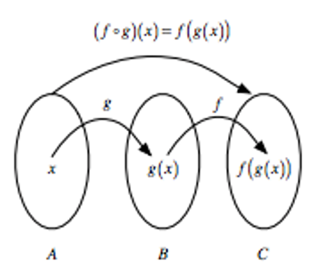

### 2.1.4 [Slice](https://dplyr.tidyverse.org/reference/slice.html): filtrar filas según el índice numérico

Seleccionar filas concretas del set de datos

```r
recetas |>
  # shortcut para el pipe: CTRL + SHIFT + M
  slice(1) # la primera fila
```

```
# A tibble: 1 × 17
  name      country url   author date_published ingredients calories   fat carbs
  <chr>     <fct>   <chr> <chr>  <date>         <chr>          <dbl> <dbl> <dbl>
1 Saganaki… Greek   http… John … 2024-02-07     1 (4 ounce…      391    25    15
# ℹ 8 more variables: protein <dbl>, avg_rating <dbl>, total_ratings <dbl>,
#   reviews <dbl>, prep_time <dbl>, cook_time <dbl>, total_time <dbl>,
#   servings <fct>
```

```r
recetas |>
  slice(1, 5) # la fila 1 y la 5
```

```
# A tibble: 2 × 17
  name      country url   author date_published ingredients calories   fat carbs
  <chr>     <fct>   <chr> <chr>  <date>         <chr>          <dbl> <dbl> <dbl>
1 Saganaki… Greek   http… John … 2024-02-07     1 (4 ounce…      391    25    15
2 Tex-Mex … Tex-Mex http… Ann    2025-02-18     2 cups all…      449    23    58
# ℹ 8 more variables: protein <dbl>, avg_rating <dbl>, total_ratings <dbl>,
#   reviews <dbl>, prep_time <dbl>, cook_time <dbl>, total_time <dbl>,
#   servings <fct>
```

```r
recetas |>
  slice(1:5) # de la fila 1 a la 5
```

```
# A tibble: 5 × 17
  name      country url   author date_published ingredients calories   fat carbs
  <chr>     <fct>   <chr> <chr>  <date>         <chr>          <dbl> <dbl> <dbl>
1 Saganaki… Greek   http… John … 2024-02-07     1 (4 ounce…      391    25    15
2 Coney Is… Jewish  http… John … 2024-11-26     2 ¾ cups a…      301    17    31
3 Diana's … Austra… http… CHIPP… 2022-07-14     1 ½ cups w…       64     3     9
4 Chilean … Chilean http… Heidi  2025-01-31     ½ cup chop…      106     9     7
5 Tex-Mex … Tex-Mex http… Ann    2025-02-18     2 cups all…      449    23    58
# ℹ 8 more variables: protein <dbl>, avg_rating <dbl>, total_ratings <dbl>,
#   reviews <dbl>, prep_time <dbl>, cook_time <dbl>, total_time <dbl>,
#   servings <fct>
```

```r
recetas |>
  slice(-c(1:5)) # todas las filas excepto de la 1 a la 5
```

```
# A tibble: 2,213 × 17
   name     country url   author date_published ingredients calories   fat carbs
   <chr>    <fct>   <chr> <chr>  <date>         <chr>          <dbl> <dbl> <dbl>
 1 Newfoun… Canadi… http… MomWh… 2022-08-12     1 (3 pound…      958    24   144
 2 Pasta e… Italian http… Buckw… 2023-12-12     1 cup dry …      378    10    59
 3 Danish … Danish  http… TheOt… 2020-06-19     4 cups all…       90     5    10
 4 Lemon P… Amish … http… Laura… 2025-01-21     2 cups all…      157     6    25
 5 Pan con… Spanish http… Luis … 2025-06-02     1 large to…      322    16    39
 6 Traci's… Filipi… http… Traci… 2022-08-28     2 tablespo…        4     0     1
 7 Brazili… Brazil… http… JESSY… 2022-09-25     1 cup whit…       NA    NA    NA
 8 Lomo de… Cuban   http… lillo… 2024-12-19     1 tablespo…      389    21    16
 9 Peruvia… Peruvi… http… Kat N… 2022-09-15     1 gallon w…      253     2    63
10 Chef Jo… Southe… http… John … 2023-12-08     1  whole c…     1115    66    75
# ℹ 2,203 more rows
# ℹ 8 more variables: protein <dbl>, avg_rating <dbl>, total_ratings <dbl>,
#   reviews <dbl>, prep_time <dbl>, cook_time <dbl>, total_time <dbl>,
#   servings <fct>
```